# Phylogenetic Analysis

Klaus Schliep

18/03/2024

## Setup

First we load the *phangorn* package, read in the alignment and also again the csv file.

```r
library(phangorn)
tab <- read.csv("cats_dogs.csv")
head(tab)
```

```
##               Latin_name          Common_name     Family       CYTB
## 1 Canis lupus familiaris                  dog    Canidae EU352854.1
## 2  Mustela putorius furo      domestic ferret Mustelidae   EF987746
## 3      Odobenus rosmarus       Pacific walrus Odobenidae GU174611.1
## 4            Lutra lutra Eurasian river otter Mustelidae   AF057124
## 5          Neogale vison        American mink Mustelidae   AF057129
## 6       Mustela nigripes  black-footed ferret Mustelidae   EF987743
```

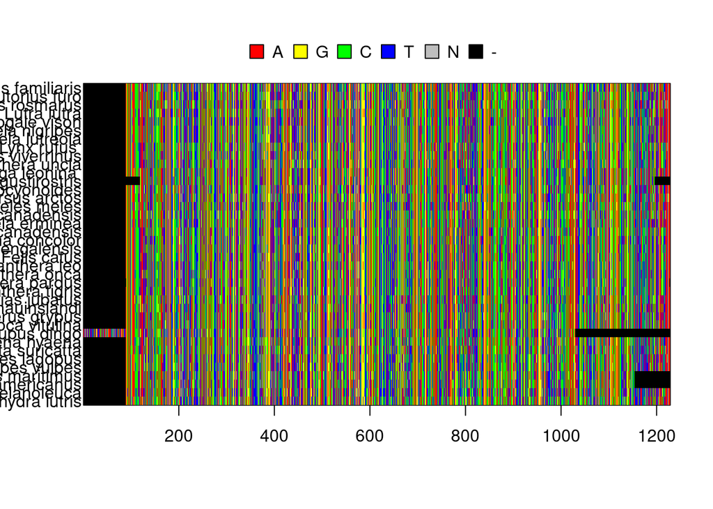

```r
align <- read.phyDat("cats_dogs_mafft.fasta", format="fasta")
names(align) <- tab$Latin_name
image(align)
```

## Distance based methods, Neighbor Joining

Neighbor Joining needs a distance matrix as input. So we first create a distance matrix:

```r
dm <- dist.ml(align, "F81", exclude = "pairwise")
```

Using the distance matrix we can compute a Neighbor Joining (NJ) or UPGMA tree.

```r
tree_NJ <- NJ(dm)
tree_UPGMA <- upgma(dm)
```

And we can plot these trees using the plot function:

```r
par(mar = c(1,1,2,1)) # smaller margins
plot(midpoint(tree_NJ), cex = 0.5)
plot(tree_UPGMA, cex = 0.5)
```

[output not shown]

What is the difference between the 2 trees?

You can get a lot of inspiration if you look into the help typing `?plot.phylo`. You can check what the arguments do but many function also have some examples and you can click on a link `run examples` it will just do this and can get see what different arguments in use.

Now we export the 2 trees so that they can read into other programs (e.g. figtree or dendrogram) or use another time.

```r
write.tree(tree_NJ, file="results/tree_NJ.phy")
write.tree(tree_UPGMA, "results/tree_UPGMA.phy")
```

Always make sure that each steps work. Check that the files contain a Newick string.

## Maximum Parsimony

Next we perform Maximum Parsimony. Here we need only one command to execute and it will return a tree, which already has bootstrap values assigned to it.

```r
set.seed(42)
tree_MP <- pratchet(align, trace=0)
# we need to run this function ro assign edge length to the tree
tree_MP <- acctran(tree_MP, align)
```

We now can use the function **plotBS** plots the tree with Bootstrap values. Check out the help of `?plotBS` to search for a parameter to plot only “large” values.

```r
par(mar = c(1,1,2,1)) # smaller margins
plotBS(tree_MP, type = "phylogram")
```

[output not shown]

Try different **types** of the trees. Which one do you like most?

We artificial root the tree as it looks a bit better and add a `scalebar` and title to the plot.

```r
plotBS(midpoint(tree_MP), type = "phylogram", main="Maximum Parsimony")
add.scale.bar()
```

[output not shown]

Clicking on **export** button in Plots tab you can save each graphic. Much nicer than doing screen shots!!

Export the tree and check that the tree is in Newick format.

```r
write.tree(tree_MP, "results/tree_MP.phy")
```

## Maximum Likelihood Analysis

Maximum Likelihood needs to set and optimize a lot of parameters. **modelTest** is a little helper functions which guides us to selecting the best model for your data set. We estimate some of the most common models.

```r
set.seed(42)
mt <- modelTest(align, model = c("JC", "F81", "K80", "HKY", "SYM", "GTR"),
                control = pml.control(trace=0))
mt
```

```
##         Model df    logLik      AIC          AICw     AICc         AICcw
## 1          JC 73 -17361.44 34868.89  0.000000e+00 34878.25  0.000000e+00
## 2        JC+I 74 -15841.61 31831.22  0.000000e+00 31840.85  0.000000e+00
## 3     JC+G(4) 74 -15756.76 31661.53  0.000000e+00 31671.15  0.000000e+00
## 4   JC+G(4)+I 75 -15689.46 31528.92  0.000000e+00 31538.81  0.000000e+00
## 5         F81 76 -17286.72 34725.44  0.000000e+00 34735.60  0.000000e+00
## 6       F81+I 77 -15688.22 31530.45  0.000000e+00 31540.89  0.000000e+00
## 7    F81+G(4) 77 -15586.81 31327.62  0.000000e+00 31338.06  0.000000e+00
## 8  F81+G(4)+I 78 -15517.26 31190.52  0.000000e+00 31201.24  0.000000e+00
## 9         K80 74 -15952.38 32052.75  0.000000e+00 32062.38  0.000000e+00
## 10      K80+I 75 -14372.52 28895.04 5.558062e-258 28904.94 1.749191e-257
## 11   K80+G(4) 75 -14249.42 28648.84 1.608759e-204 28658.74 5.062963e-204
## 12 K80+G(4)+I 76 -14175.47 28502.95 7.716192e-173 28513.12 2.118836e-172
## 13        HKY 77 -15833.79 31821.58  0.000000e+00 31832.02  0.000000e+00
## 14      HKY+I 78 -14069.23 28294.45 1.450116e-127 28305.18 3.013568e-127
```

[output cut: 35 more lines]

What is the best (lowest) fitting model according to the Akaike Informaton Criteria (AIC) and the Bayesian Information Criteria (BIC) for your dataset? Are AIC and the BIC agreeing? We can use this object to optimize the tree with the best fitting model!

```r
set.seed(42)
fit <- pml_bb(mt, control=pml.control(trace=0))
fit
```

```
## model: GTR+G(4)+I
## loglikelihood: -13753.84
## unconstrained loglikelihood: -6059.853
## Proportion of invariant sites: 0.4707058
## Model of rate heterogeneity: Discrete gamma model
## Number of rate categories: 4
## Shape parameter: 1.765562
##        Rate Proportion
## 1 0.0000000  0.4707058
## 2 0.4979993  0.1323235
## 3 1.1855775  0.1323235
## 4 2.0080347  0.1323235
## 5 3.8656228  0.1323235
##
## Rate matrix:
##           a          c          g         t
## a  0.000000  8.4338789 54.0011092  3.515634
## c  8.433879  0.0000000  0.7211303 68.617022
## g 54.001109  0.7211303  0.0000000  1.000000
## t  3.515634 68.6170221  1.0000000  0.000000
##
## Base frequencies:
##         a         c         g         t
## 0.2935293 0.2987161 0.1363911 0.2713634
```

We can extract the Maximum likelihood tree from the fit object using the `$` sign.

```r
tree_ML <- fit$tree
```

We now can do a seperate bootstrap run. The development version of phangorn (on the server) does implicitly a so called “ultrafast” bootstrap [@minh2013]. We also extract these trees.

```r
tree_bs <- fit$bs
```

We now can use the function **plotBS** to plot the tree with Bootstrap values to the tree. Look for a parameter to plot only support values if these are larger than a threshold, e.g. 80%.

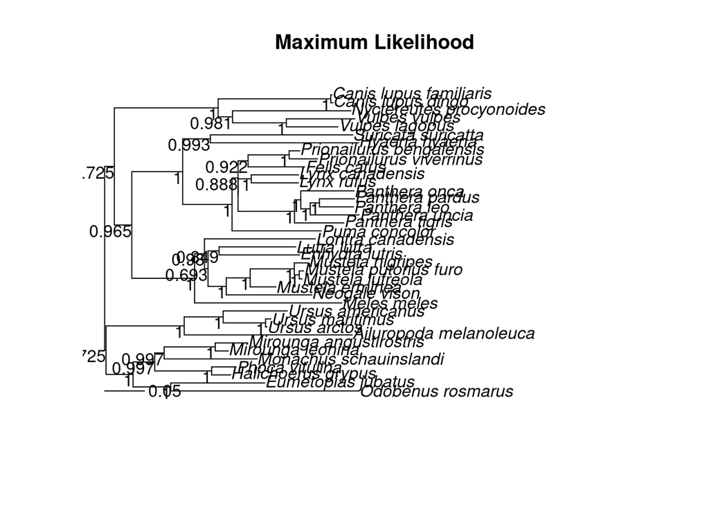

```r
# use plotBS to assign bootstrap values to plot_ML
tree_ML <- plotBS(tree_ML, tree_bs, type = "none", main="Maximum Likelihood")

plotBS(midpoint(tree_ML), type = "p", main="Maximum Likelihood")
add.scale.bar()
```

In the console you can also execute the command `add.scale.bar(ask=TRUE)`

Export the tree.

```r
write.tree(tree_ML, "results/tree_ML.phy")
```

## Plotting trees

We seen already two functions to plot trees `plotBS` and `plot`, which is actually a function called `plot.phylo`. `plotBS` is based on `plot.phylo` adding the bootstrap values on the tree, but otherwise can take all the parameters of `plot.phylo`.

### Adding color to a tree

We can change the color of the tips setting the argument `tip.color`.

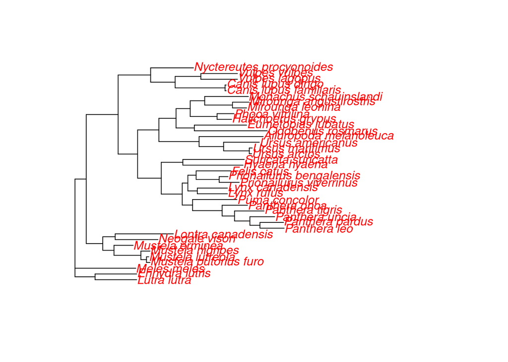

```r
plot(tree_MP, tip.color="red")
```

If `tip.color` has only one value than all tips colored in that color. If `tip.color` is a vector than it will color the tips with different colors. The order of the labels is given by `tree_MP$tip.label`.

```r
head(tab)
```

```
##               Latin_name          Common_name     Family       CYTB
## 1 Canis lupus familiaris                  dog    Canidae EU352854.1
## 2  Mustela putorius furo      domestic ferret Mustelidae   EF987746
## 3      Odobenus rosmarus       Pacific walrus Odobenidae GU174611.1
## 4            Lutra lutra Eurasian river otter Mustelidae   AF057124
## 5          Neogale vison        American mink Mustelidae   AF057129
## 6       Mustela nigripes  black-footed ferret Mustelidae   EF987743
```

If look at the `Family` column, we can see that there are 9 different families.

```r
unique(tab$Family)
```

```
## [1] "Canidae"     "Mustelidae"  "Odobenidae"  "Felidae"     "Phocidae"
## [6] "Ursidae"     "Otariidae"   "Hyaenidae"   "Herpestidae"
```

```r
col <- c("green", "blue", "lightblue", "red", "orange", "brown", "yellow", "darkgreen", "magenta")
col <- setNames(col, unique(tab$Family))
tip_color <- col[tab$Family]
tip_color <- setNames(tip_color, tab$Latin_name)
```

And finally we can plot the tree and also color the tip labels with different colors for the families. We also add a legend to see which color correspondents to each family.

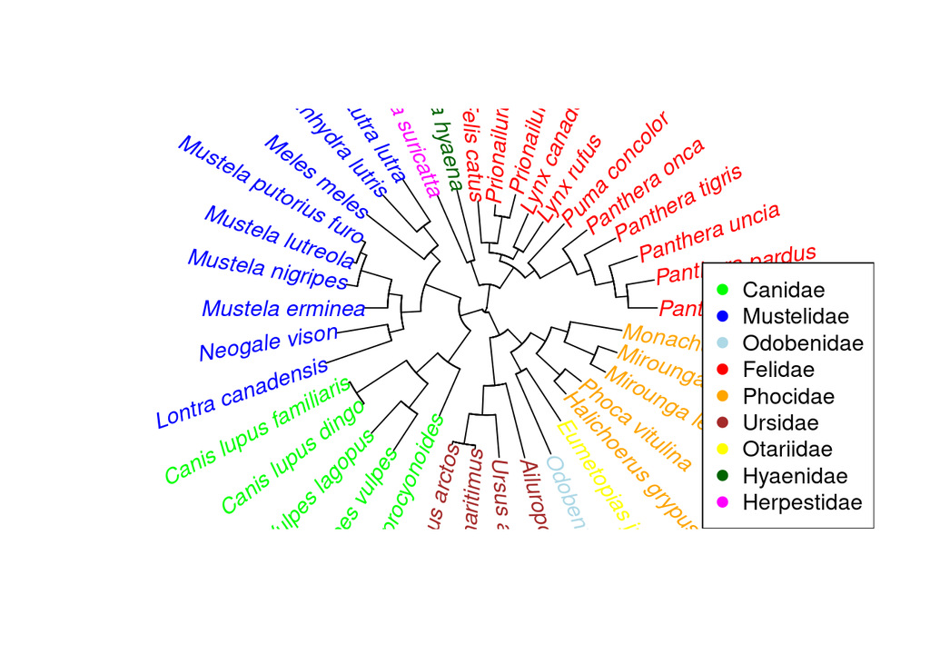

```r
plot(midpoint(tree_MP), type="fan", tip.col=tip_color[tree_MP$tip.label])


legend("bottomright", unique(tab$Family), col=col, pch=19)
```

## Comparing trees

1. Are the NJ, UPGMA, Maximum Parsimony and the Maximum Likelihood tree the same?
2. What trees are more similar?

When you executed all code chunks above you should have all the files in the results folder and can reload them again

```r
library(phangorn)
# Read in the trees if they are not in the environment any more
tree_MP <- read.tree("results/tree_MP.phy")
tree_ML <- read.tree("results/tree_ML.phy")
tree_NJ <- read.tree("results/tree_NJ.phy")
tree_UPGMA <- read.tree("results/tree_UPGMA.phy")
```

One way to compare trees is using the Robinson-Foulds (RF) distance [@Robinson1981]. Here we build a distance matrix between all trees we computed. Which ones are more similar?

```r
dm_RF <- RF.dist(c(tree_NJ, tree_UPGMA, tree_MP, tree_ML))
dm_RF <- as.matrix(dm_RF)
dimnames(dm_RF) <- list(c("NJ", "UPGMA", "MP", "ML"), c("NJ", "UPGMA", "MP", "ML"))
dm_RF
```

```
##       NJ UPGMA MP ML
## NJ     0     8 16 12
## UPGMA  8     0 16 12
## MP    16    16  0 16
## ML    12    12 16  0
```

To compare two trees (also) there is the following function.

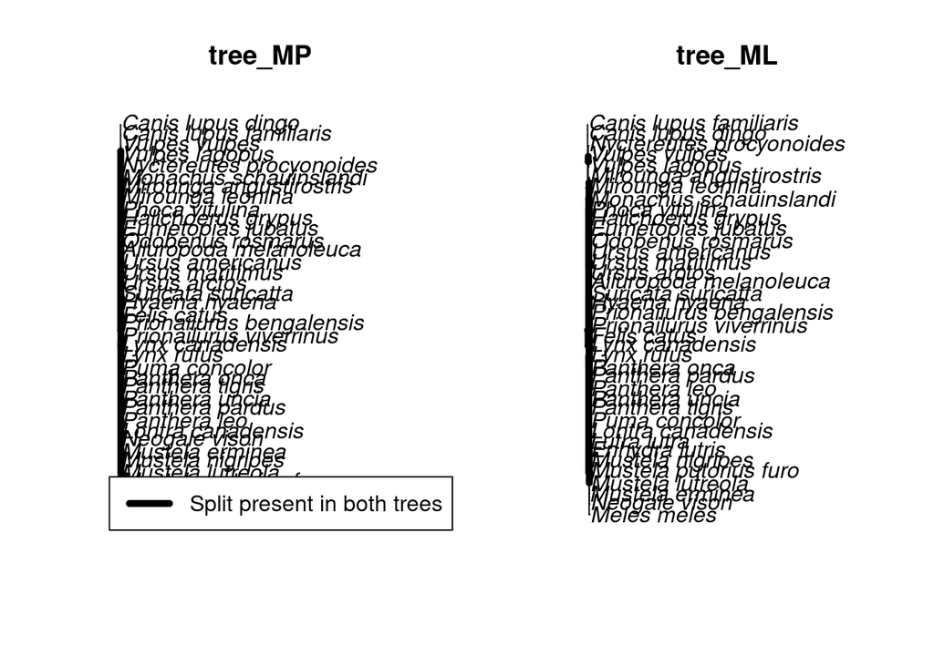

```
## => Comparing tree_MP with tree_ML.
## Both trees have the same number of tips: 38.
## Both trees have the same tip labels.
## Both trees have the same number of nodes: 36.
## Both trees are unrooted.
## Both trees are not ultrametric.
## 28 splits in common.
```

```r
comparePhylo(tree_MP, tree_ML, plot=TRUE, type="p",
             use.edge.length = TRUE)
```

Change plotting style, e.g. plotting an unrooted tree in stead of a phylogram. It is possible to change the font size and have flexibility to move the legend around.

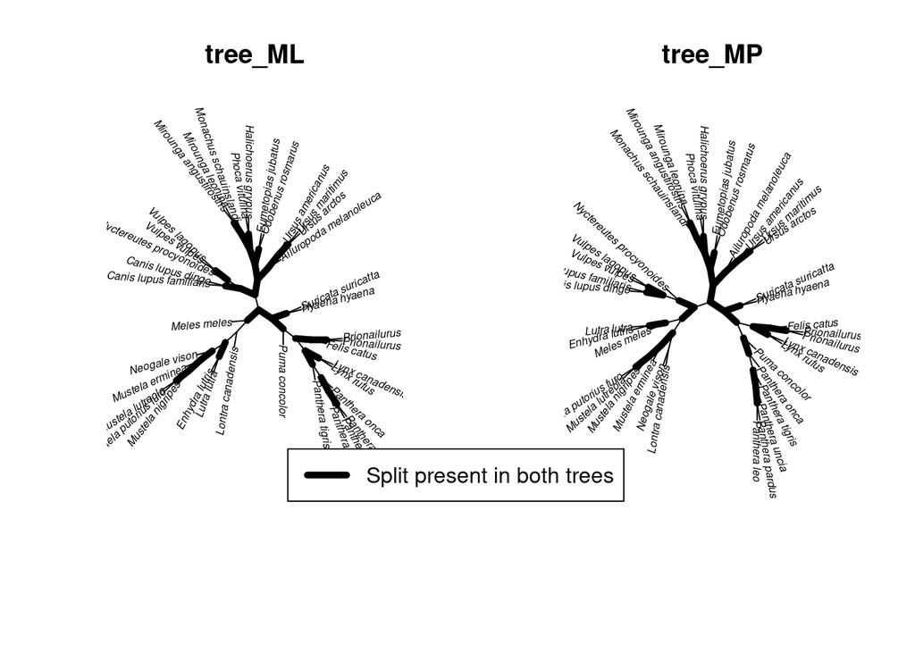

```
## => Comparing tree_ML with tree_MP.
## Both trees have the same number of tips: 38.
## Both trees have the same tip labels.
## Both trees have the same number of nodes: 36.
## Both trees are unrooted.
## Both trees are not ultrametric.
## 28 splits in common.
```

```r
comparePhylo(tree_ML, tree_MP, plot=TRUE, type="unrooted", lab4ut="axial", location = list(x = 8, y = -2), cex=.5)
```

I prefer often to highlight differences not shared splits.

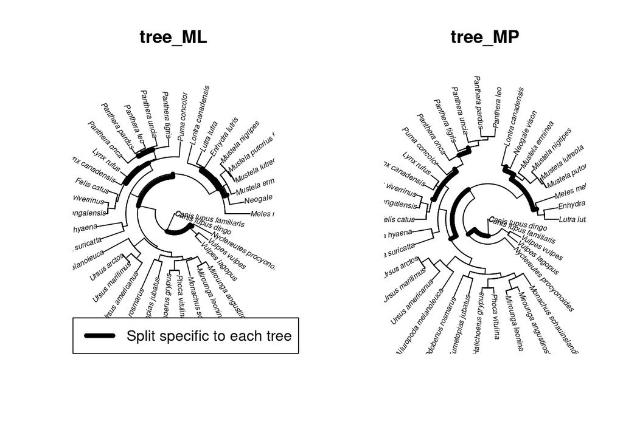

```
## => Comparing tree_ML with tree_MP.
## Both trees have the same number of tips: 38.
## Both trees have the same tip labels.
## Both trees have the same number of nodes: 36.
## Both trees are unrooted.
## Both trees are not ultrametric.
## 28 splits in common.
```

```r
comparePhylo(tree_ML, tree_MP, plot=TRUE, lab4ut="axial", type="fan",
             cex=.5, commons=FALSE, use.edge.length = TRUE)
```

When comparing different trees from different genes or gene trees with the species tree often the often the sets of species differ. In such a case we can prune all the trees to have the same tip label first.